```python
import os
for dirname, _, filenames in os.walk('/kaggle/input'):
    for filename in filenames:
        print(os.path.join(dirname, filename))

import seaborn as sns
import pandas as pd
import matplotlib.pyplot as plt

from sklearn import preprocessing
from sklearn.model_selection import train_test_split, GridSearchCV
from sklearn.ensemble import RandomForestClassifier
from sklearn.metrics import confusion_matrix, ConfusionMatrixDisplay, precision_score, accuracy_score, f1_score
from sklearn.inspection import permutation_importance
```

# Crop Prediction dataset

In this notebook we will explore the ["Crop prediction"](http://www.kaggle.com/datasets/sanamps/crop-prediction) dataset and we will use this data to create a ML model. The dataset has numerous observation from different fields in India. For each field we find:

- N - ratio of Nitrogen content in soil;
- P - ratio of Phosphorous content in soil;
- K - ratio of Potassium content in soil;
- temperature - temperature in degree Celsius;
- humidity - relative humidity in %;
- ph - ph value of the soil;
- rainfall - rainfall in mm;
- label - crop that is cultivate in the field.

We will first explore the data, then reply to some questions regarding the different crops and finally deply a ML model to predict from the characteristics of a field which is the best crop to cultivate there.

```python
df= pd.read_csv("Crop_recommendation.csv")
```

# Data exploration

We look at the dataframe shape, we check for NaNs, we take a look at the data type in each column and finally we obtain a first hint on the variables distribution computing for the continuous ones mean, std, quantiles, min and max. For the only categorical variable we check which values it can take and the frequency of each class.

```python
print(f"The dataframe df has {df.shape[0]} rows and {df.shape[1]} columns")
```

```
The dataframe df has 2200 rows and 8 columns
```

```python
df.info()
```

```
<class 'pandas.core.frame.DataFrame'>
RangeIndex: 2200 entries, 0 to 2199
Data columns (total 8 columns):
 #   Column       Non-Null Count  Dtype
---  ------       --------------  -----
 0   N            2200 non-null   int64
 1   P            2200 non-null   int64
 2   K            2200 non-null   int64
 3   temperature  2200 non-null   float64
 4   humidity     2200 non-null   float64
 5   ph           2200 non-null   float64
 6   rainfall     2200 non-null   float64
 7   label        2200 non-null   object
dtypes: float64(4), int64(3), object(1)
memory usage: 137.6+ KB
```

```python
df.describe()
```

|  | N | P | K | temperature | humidity | ph | rainfall |
| --- | --- | --- | --- | --- | --- | --- | --- |
| count | 2200.000000 | 2200.000000 | 2200.000000 | 2200.000000 | 2200.000000 | 2200.000000 | 2200.000000 |
| mean | 50.551818 | 53.362727 | 48.149091 | 25.616244 | 71.481779 | 6.469480 | 103.463655 |
| std | 36.917334 | 32.985883 | 50.647931 | 5.063749 | 22.263812 | 0.773938 | 54.958389 |
| min | 0.000000 | 5.000000 | 5.000000 | 8.825675 | 14.258040 | 3.504752 | 20.211267 |
| 25% | 21.000000 | 28.000000 | 20.000000 | 22.769375 | 60.261953 | 5.971693 | 64.551686 |
| 50% | 37.000000 | 51.000000 | 32.000000 | 25.598693 | 80.473146 | 6.425045 | 94.867624 |
| 75% | 84.250000 | 68.000000 | 49.000000 | 28.561654 | 89.948771 | 6.923643 | 124.267508 |
| max | 140.000000 | 145.000000 | 205.000000 | 43.675493 | 99.981876 | 9.935091 | 298.560117 |

```python
labels= list(df.label.value_counts().index)
print(labels)
print(f"There are {len(labels)} different categories.")
df.label.value_counts()
```

```
['rice', 'maize', 'jute', 'cotton', 'coconut', 'papaya', 'orange', 'apple', 'muskmelon', 'watermelon', 'grapes', 'mango', 'banana', 'pomegranate', 'lentil', 'blackgram', 'mungbean', 'mothbeans', 'pigeonpeas', 'kidneybeans', 'chickpea', 'coffee']
There are 22 different categories.
```

```
label
rice           100
maize          100
jute           100
cotton         100
coconut        100
papaya         100
orange         100
apple          100
muskmelon      100
watermelon     100
grapes         100
mango          100
banana         100
pomegranate    100
lentil         100
blackgram      100
mungbean       100
mothbeans      100
pigeonpeas     100
kidneybeans    100
chickpea       100
coffee         100
Name: count, dtype: int64
```

Our dataframe has 2200 rows and 8 columns. There are no NaNs. The variables N, P, K, humidity and rainfall have a similar scale, so it is ok to graphically represent them with the same scale. The variables ph and temperature will be represented in their own scale.

There are 22 different categories and the dataset is perfectly balanced, with 100 observations for each category.

# Data visualization

We now represent graphically the continuous variables. We first use a box-plot then a scatter-matrix The scatter matrix has on the diagonal the histogram of the variables and in the non-diagonal elements the scatter plot of each pair of variables.

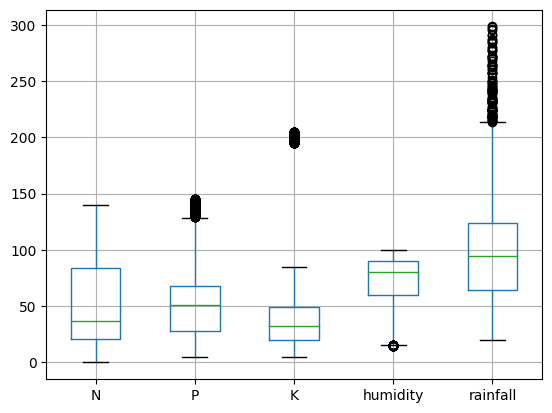

```python
df.boxplot(column= ["N", "P", "K", "humidity", "rainfall"])
plt.show()
```

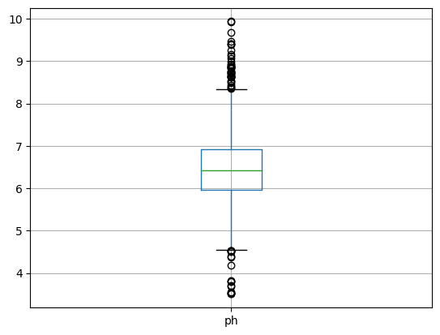

```python
df.boxplot(column= ["ph"])
plt.show()
```

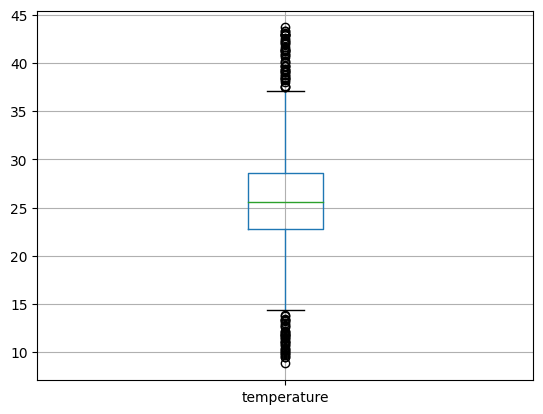

```python
df.boxplot(column= ["temperature"])
plt.show()
```

We notice that:

- the variables **P** and **rainfall** have heavy right tails;
- the variables **ph** and **temperature** are fairly symmetric around the mean;
- the variable **K** has numerous outliers clustered together.

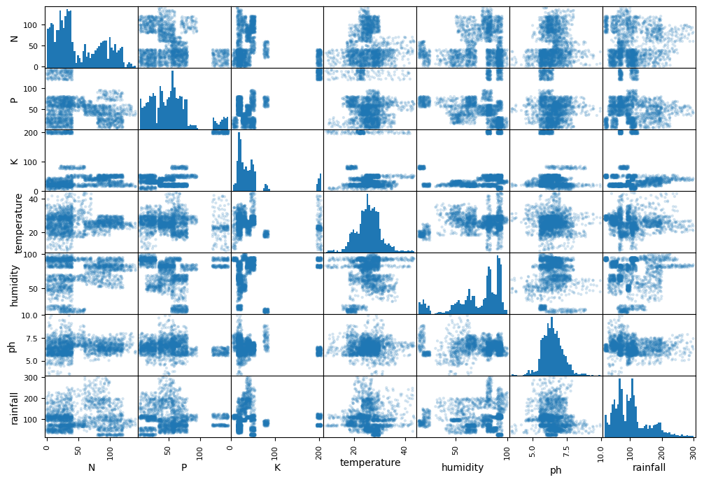

```python
pd.plotting.scatter_matrix(df, alpha=0.2, hist_kwds={"bins":50, "linewidth": .5}, figsize=(12,8))
plt.show()
```

From the scatter matrix:

- we confirm our guesses from the boxplots;
- we notice how in some scatter-plots is easy to identify clusters.

We now focus on replying to 3 questions:

1. What is the top-5 crops that on average require more rainfall?
2. What is the top-5 crops that require the lowest temperatures?
3. What is the top-5 crops that allow the highest variability in terms of humidity?

```python
df.groupby("label").rainfall.mean().sort_values(ascending= False)[0:5]
```

```
label
rice          236.181114
coconut       175.686646
jute          174.792798
coffee        158.066295
pigeonpeas    149.457564
Name: rainfall, dtype: float64
```

```python
df.groupby("label").temperature.mean().sort_values()[0:5]
```

```
label
chickpea       18.872847
kidneybeans    20.115085
pomegranate    21.837842
maize          22.389204
apple          22.630942
Name: temperature, dtype: float64
```

```python
df.groupby("label").humidity.std().sort_values(ascending= False)[0:5]
```

```
label
pigeonpeas    10.963659
mothbeans      6.994600
coffee         5.838566
jute           5.507798
maize          5.448699
Name: humidity, dtype: float64
```

We now represent the top crop in everyone of the previous ranks in a scatter matrix. We color code each crop in a different way and in the diagonal we represent the marginal probability of each crop for the different features. In order to get the marginal probability we use [**Kernel density estimation**](http://en.wikipedia.org/wiki/Kernel_density_estimation).

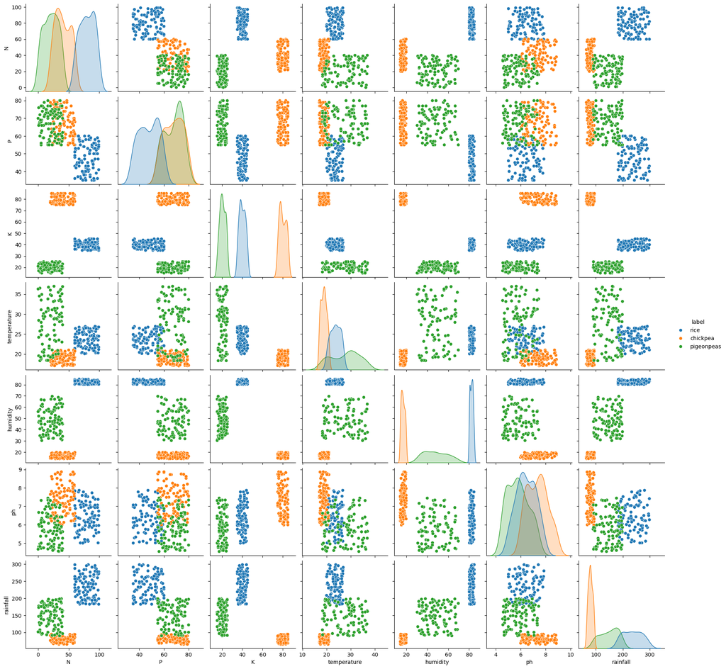

```python
sns.pairplot(df.loc[(df.label == "rice") | (df.label == "chickpea") | (df.label == "pigeonpeas")], hue="label")
plt.show()
```

# Prediction of the optimal crop from the field characteristics

In order to predict the optimal crop from the field characteristics we use Random Forrest algorithm. In order to do so:

1. we divide our dataset into training set and test set;
2. we use k-fold cross validation and a grid search approach to optimize the parameters "n_estimators" and "max_depth";
3. we take a look at the performances on the training set of the models trained with different parameters combinations;
4. we train the model with the best parameters on the whole training set;
5. we use the trainig model on unseen data (the test set) and evaluate its performances using accuracy, precision, f1-score and by visualizing the confusion matrix.

We test with Grid Search relatively simple models, since the data has good quality and from the scatterplots we can suppose that the different groups are well characterized.

```python
features= df.drop(columns=['label'])

x_train, x_test, y_train, y_test= train_test_split(features, df['label'], stratify= df['label'])

rf= RandomForestClassifier()
parameters= {"n_estimators": [2, 4, 6, 8, 10, 12], "max_depth": [2, 4, 6, 8, 10]}

cv= GridSearchCV(rf, parameters, cv=5, verbose=3)
```

```python
cv.fit(x_train, y_train)

cv_results= pd.DataFrame(cv.cv_results_)
```

[output not shown]

[output cut: 96 more lines]

[output not shown]

```python
cv_results.columns

cv_results[["param_max_depth", "param_n_estimators", "mean_test_score", "std_test_score", "rank_test_score", "mean_fit_time", "std_fit_time"]]
```

|  | param_max_depth | param_n_estimators | mean_test_score | std_test_score | rank_test_score | mean_fit_time | std_fit_time |
| --- | --- | --- | --- | --- | --- | --- | --- |
| 0 | 2 | 2 | 0.252727 | 0.048885 | 30 | 0.004984 | 0.001727 |
| 1 | 2 | 4 | 0.406667 | 0.065986 | 29 | 0.005307 | 0.000219 |
| 2 | 2 | 6 | 0.561212 | 0.091822 | 27 | 0.007256 | 0.001967 |
| 3 | 2 | 8 | 0.624242 | 0.105618 | 26 | 0.007642 | 0.000126 |
| 4 | 2 | 10 | 0.683030 | 0.072869 | 25 | 0.009071 | 0.000178 |
| 5 | 2 | 12 | 0.728485 | 0.060533 | 24 | 0.010526 | 0.000343 |
| 6 | 4 | 2 | 0.510303 | 0.050182 | 28 | 0.003336 | 0.000086 |
| 7 | 4 | 4 | 0.806667 | 0.036535 | 23 | 0.005302 | 0.000093 |
| 8 | 4 | 6 | 0.850303 | 0.069303 | 21 | 0.007297 | 0.000117 |
| 9 | 4 | 8 | 0.884242 | 0.036029 | 20 | 0.009783 | 0.000591 |
| 10 | 4 | 10 | 0.903636 | 0.031222 | 19 | 0.011839 | 0.001038 |
| 11 | 4 | 12 | 0.921818 | 0.022465 | 18 | 0.012957 | 0.000195 |
| 12 | 6 | 2 | 0.847273 | 0.058245 | 22 | 0.003627 | 0.000079 |
| 13 | 6 | 4 | 0.936364 | 0.016487 | 16 | 0.006076 | 0.000272 |
| 14 | 6 | 6 | 0.967273 | 0.015260 | 13 | 0.008312 | 0.000176 |
| 15 | 6 | 8 | 0.966061 | 0.014136 | 14 | 0.010453 | 0.000077 |
| 16 | 6 | 10 | 0.980606 | 0.007809 | 10 | 0.013066 | 0.000234 |
| 17 | 6 | 12 | 0.973333 | 0.010032 | 11 | 0.015992 | 0.000550 |
| 18 | 8 | 2 | 0.926667 | 0.013740 | 17 | 0.004278 | 0.000357 |
| 19 | 8 | 4 | 0.973333 | 0.014265 | 11 | 0.006707 | 0.000218 |
| 20 | 8 | 6 | 0.989091 | 0.005938 | 6 | 0.009315 | 0.000232 |
| 21 | 8 | 8 | 0.989091 | 0.004535 | 6 | 0.011740 | 0.000412 |
| 22 | 8 | 10 | 0.990909 | 0.002710 | 2 | 0.013960 | 0.000138 |
| 23 | 8 | 12 | 0.989697 | 0.004924 | 5 | 0.016920 | 0.000574 |
| 24 | 10 | 2 | 0.950909 | 0.022301 | 15 | 0.004066 | 0.000135 |
| 25 | 10 | 4 | 0.985455 | 0.003534 | 9 | 0.006480 | 0.000095 |
| 26 | 10 | 6 | 0.988485 | 0.004848 | 8 | 0.009406 | 0.000170 |
| 27 | 10 | 8 | 0.990909 | 0.003833 | 2 | 0.012022 | 0.000133 |
| 28 | 10 | 10 | 0.995758 | 0.002424 | 1 | 0.015188 | 0.000413 |
| 29 | 10 | 12 | 0.990909 | 0.005421 | 2 | 0.017585 | 0.000180 |

```python
print(cv.best_params_)
print(cv.best_score_)
```

```
{'max_depth': 10, 'n_estimators': 10}
0.9957575757575757
```

```python
rf= RandomForestClassifier(**cv.best_params_)
rf.fit(x_train, y_train)
```

```
RandomForestClassifier(max_depth=10, n_estimators=10)
```

```
The precision score is 0.9819405594405595, the accuracyscore is 0.9818181818181818,and the f1-score is 0.9818123613081595
```

[figure not shown]

```python
y_pred= rf.predict(x_test)
short_labels= [word[0:3] for word in labels]
cm = confusion_matrix(y_test, y_pred)
disp= ConfusionMatrixDisplay(cm, display_labels= short_labels).plot()

fig = disp.figure_
fig.set_figwidth(10)
fig.set_figheight(10)
fig.suptitle('Plot of confusion matrix')

print(f"The precision score is {precision_score(y_test, y_pred, average='weighted')}, the accuracy"
      f"score is {accuracy_score(y_test, y_pred)},"
      f"and the f1-score is {f1_score(y_test, y_pred, average='weighted')}")

plt.show()
```

Before commenting on the model performances, we check what are the most importan features in our model and visualize them.

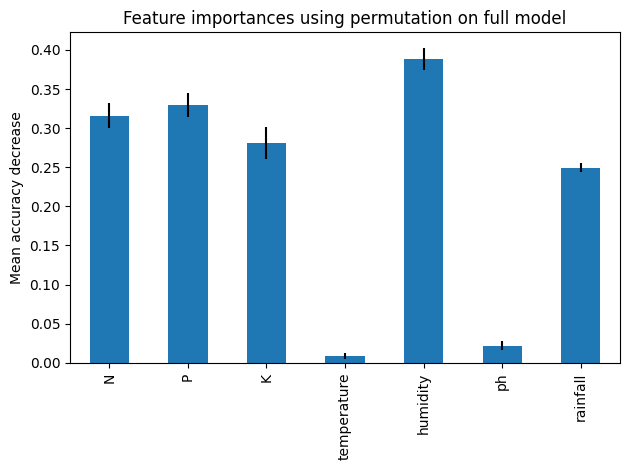

```python
feature_names= list(df.columns)
feature_names.remove('label')

result= permutation_importance(rf, x_test, y_test, n_repeats=10, random_state=42)

forest_importances= pd.Series(result.importances_mean, index=feature_names)

fig, ax= plt.subplots()
forest_importances.plot.bar(yerr=result.importances_std, ax=ax)
ax.set_title("Feature importances using permutation on full model")
ax.set_ylabel("Mean accuracy decrease")
fig.tight_layout()
plt.show()
```

We notice from the feature importance plot that the most impoprtant feature is **humidity**, followed by **P** and **N**. The least important features are **temperature** and **ph**.

The model performs in a extremely good way. It shows really good prediction power with overall precision, accuracy and f1-score > 0.98, all of this with a relatively simple model made of 10 trees with a maximum depth of 10. Models with 4 trees having a max depth of 6 already show good performances on the training set.

The reason for this good performance, other than the parameter optimization and the fact that the dataset is quite simple, can be found in the good quality of the data, that is perfectly balanced and shows a strong characterization for the various features, as one can notice from the clusters in the scatter matrix.